# 1일차

```python
s = 'hello'

print(s)
```

```
hello
```

```python
print(s + 'hi')
```

```
hellohi
```

# Pandas

## Pandas

### Pandas

#### Pandas

##### Pandas

- Panel Data Analysis
- show
- me
- the
- money

## 제목

*제목*입니다.  
두 번째 **제목**입니다.

[figure not shown]

## Pandas

- Panel Data Analysis
- 파이썬에서 데이터프레임(Data Frame)을 다루는 도구
- pip install pandas
- https://pandas.pydata.org/pandas-docs/stable/index.html 참조

[figure not shown]

## Data Frame

- 데이터가 틀에 맞춰서 저장된 형태, 데이터를 가로 x 세로 직사각형 모양으로 틀을 갖춰 저장
- 스프레드 시트, 테이블, 엑셀, 데이터 프레임 분야마다 다르게 불림
- 가로(행)를 row라 하고, 세로(열)를 column이라 함
- 한 row 안에 데이터는 Dictionary 처럼 저장
- 한 column 안에 데이터는 List 처럼 저장
- 한 데이터 프레임은 row들이 List 처럼 저장

```python
# pandas를 불러와 pd라는 축약어로 사용
import pandas as pd

all_list = []
all_list.append({'date':'2022-03-19', 'dayofweek':'sat'})
all_list.append({'date':'2022-03-20', 'dayofweek':'sun'})
all_list.append({'date':'2022-03-21', 'dayofweek':'mon'})
all_list
```

```
[{'date': '2022-03-19', 'dayofweek': 'sat'},
 {'date': '2022-03-20', 'dayofweek': 'sun'},
 {'date': '2022-03-21', 'dayofweek': 'mon'}]
```

```python
df = pd.DataFrame(all_list)
df
```

|  | date | dayofweek |
| --- | --- | --- |
| 0 | 2022-03-19 | sat |
| 1 | 2022-03-20 | sun |
| 2 | 2022-03-21 | mon |

```python
# Data Frame을 만드는 다양한 방식
name = ['jo', 'kim', 'lee', 'choi', 'park']
age = [22, 31, 55, 17, 27]

DataSet = list(zip(name, age))
df = pd.DataFrame(data=DataSet, columns=['name', 'age'])
df
```

|  | name | age |
| --- | --- | --- |
| 0 | jo | 22 |
| 1 | kim | 31 |
| 2 | lee | 55 |
| 3 | choi | 17 |
| 4 | park | 27 |

```python
number = [1, 2, 3]
letters = ['a', 'b', 'c']

for pair in zip(number, letters):
    print(pair)
```

```
(1, 'a')
(2, 'b')
(3, 'c')
```

```python
df.dtypes
```

```
name    object
age      int64
dtype: object
```

```python
df.index
```

```
RangeIndex(start=0, stop=5, step=1)
```

```python
df.columns
```

```
Index(['name', 'age'], dtype='object')
```

```python
df['name']
```

```
0      jo
1     kim
2     lee
3    choi
4    park
Name: name, dtype: object
```

```python
df
```

|  | name | age |
| --- | --- | --- |
| 0 | jo | 22 |
| 1 | kim | 31 |
| 2 | lee | 55 |
| 3 | choi | 17 |
| 4 | park | 27 |

```python
df[0:2]
```

|  | name | age |
| --- | --- | --- |
| 0 | jo | 22 |
| 1 | kim | 31 |

```python
# filtering
df[df['age'] > 30]
```

|  | name | age |
| --- | --- | --- |
| 1 | kim | 31 |
| 2 | lee | 55 |

```python
df[df['age'] < 30]
```

|  | name | age |
| --- | --- | --- |
| 0 | jo | 22 |
| 3 | choi | 17 |
| 4 | park | 27 |

```python
df['age'].mean()
```

```
30.4
```

## Numpy

- Numerical Python
- 파이썬 기반의 수치해석 라이브러리
- 선형대수 연산에 필요한 다차원 배열과 배열 연산을 수행하는 다양한 함수 제공
- pip install numpy
- https://www.numpy.org/ 참조

```python
import numpy as np

arr1 = np.array([1, 3, 5, 7, 9])
arr1
```

```
array([1, 3, 5, 7, 9])
```

```python
arr1.shape
```

```
(5,)
```

```python
arr2 = np.array([[1, 3, 5, 7, 9], [2, 4, 6, 8, 10]])
arr2
```

```
array([[ 1,  3,  5,  7,  9],
       [ 2,  4,  6,  8, 10]])
```

```python
arr2.shape
```

```
(2, 5)
```

```python
arr3 = arr2.reshape(5, 2)
arr3
```

```
array([[ 1,  3],
       [ 5,  7],
       [ 9,  2],
       [ 4,  6],
       [ 8, 10]])
```

```python
arr4 = arr3.reshape(1, 10)
arr4
```

```
array([[ 1,  3,  5,  7,  9,  2,  4,  6,  8, 10]])
```

```python
arr5 = np.zeros((2, 5))
arr5
```

```
array([[0., 0., 0., 0., 0.],
       [0., 0., 0., 0., 0.]])
```

## Matplotlib

- math plot library
- 데이터를 시각화해주는 라이브러리
- https://matplotlib.org/ 참조

```python
df
```

|  | name | age |
| --- | --- | --- |
| 0 | jo | 22 |
| 1 | kim | 31 |
| 2 | lee | 55 |
| 3 | choi | 17 |
| 4 | park | 27 |

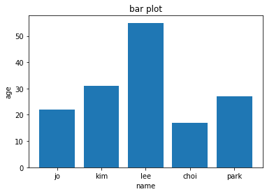

```python
%matplotlib inline
import matplotlib.pyplot as plt

x = df['name']
y = df['age']

plt.bar(x, y)
plt.xlabel('name')
plt.ylabel('age')
plt.title('bar plot')
plt.show()
```

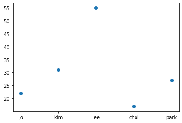

```python
plt.scatter(x, y)
plt.show()
```

## Pandas 자료구조

- Series: 1차원 배열
- Data Frame: 2차원 배열

## Series

- 데이터가 순차적으로 나열된 1차원 배열 형태
- Index는 Value와 1:1 대응됨, Index는 Value의 위치를 나타내는 역할
- 키(k)와 값(v)이 '{k:v}' 형태로 짝을 이루는 파이썬의 Dictionary와 비슷한 구조를 갖음
- Dictionary의 k -> Series의 Index로,
- Dictionary의 v -> Series의 Value로 변환해서 사용

```python
dic = {'a':1, 'b':2, 'c':3}
sr = pd.Series(dic)
sr
```

```
a    1
b    2
c    3
dtype: int64
```

```python
type(sr)
```

```
pandas.core.series.Series
```

```python
ls = ['jo', 'kim', 'lee', 'choi', 'park']
sr = pd.Series(ls)
sr
```

```
0      jo
1     kim
2     lee
3    choi
4    park
dtype: object
```

## Data Frame

- 행과 열로 만들어지는 2차원 배열 구조
- 여러 개의 Series들이 모여서 Data Frame을 이루는 구조
- Data Frame의 열은 각각 Series 객체로, Data Frame은 여러 개의 Series들이 같은 행 Index를 기준으로 줄지어 결합된 2차원 행렬(matrix)임

```python
# Dict -> Data Frame 변환

dic = {'c0':[1, 2, 3],
       'c1':[4, 5, 6],
       'c2':[7, 8, 9],
       'c3':[10, 11, 12],
       'c4':[13, 14, 15]}

df = pd.DataFrame(dic)
df
```

|  | c0 | c1 | c2 | c3 | c4 |
| --- | --- | --- | --- | --- | --- |
| 0 | 1 | 4 | 7 | 10 | 13 |
| 1 | 2 | 5 | 8 | 11 | 14 |
| 2 | 3 | 6 | 9 | 12 | 15 |

```python
# List -> Data Frame 변환

df = pd.DataFrame([[20224943, '컴퓨터공학', 1], [20191234, '전자공학', 2]],
                 index=['jo', 'kim'],
                 columns=['학번', '전공', '학년'])
df
```

|  | 학번 | 전공 | 학년 |
| --- | --- | --- | --- |
| jo | 20224943 | 컴퓨터공학 | 1 |
| kim | 20191234 | 전자공학 | 2 |

```python
df.index = ['lee', 'park']
df.columns = ['number', 'major', 'grade']
```

```python
df
```

|  | number | major | grade |
| --- | --- | --- | --- |
| lee | 20224943 | 컴퓨터공학 | 1 |
| park | 20191234 | 전자공학 | 2 |

```python
df.rename(index={'lee':'jo'}, inplace=True)
df.rename(columns={'number':'stunumber'}, inplace=True)
df
```

|  | stunumber | major | grade |
| --- | --- | --- | --- |
| jo | 20224943 | 컴퓨터공학 | 1 |
| park | 20191234 | 전자공학 | 2 |

```python
dic = {'국어':[95, 88, 72], '영어':[66, 80, 94], '수학': [100, 77, 89]}
df = pd.DataFrame(dic, index=['jo', 'kim', 'lee'])
df
```

|  | 국어 | 영어 | 수학 |
| --- | --- | --- | --- |
| jo | 95 | 66 | 100 |
| kim | 88 | 80 | 77 |
| lee | 72 | 94 | 89 |

```python
df2 = df[:]
```

```python
df2.drop(index='jo', inplace=True)
df2
```

|  | 국어 | 영어 | 수학 |
| --- | --- | --- | --- |
| kim | 88 | 80 | 77 |
| lee | 72 | 94 | 89 |

```python
df2.drop('국어', axis=1, inplace=True)
df2
```

|  | 영어 | 수학 |
| --- | --- | --- |
| kim | 80 | 77 |
| lee | 94 | 89 |